# II. Normal Distribution

차서연

Sep, 2020

## 정규분포의 추정

**Inference for a Normal Distribution**

### 문제상황

[figure not shown]

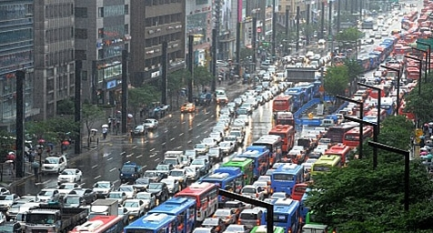

> 자동차 통행 속도는 각각 서로 다른 정규분포를 따르지 않을까?
- 서울시 2020년 8월 차량통행속도 데이터를 불러와 강남구 18시 차량통행속도의 분포를 추정하자
  - 데이터 출처: https://topis.seoul.go.kr/refRoom/openRefRoom_1.do
- 속도 데이터 $y$가 $y \sim N(\mu,\sigma^2$) 의 정규분포를 따를 것이라는 합리적인 가정 아래,
- 평균 $\mu$와 분산 $\sigma^2$를 **Stan**을 통해 베이지안 방법으로 추정해보자

```r
library(dplyr)
library(rstan)
```

### Import data

```r
data <- read.csv('velocity.csv', header = T)
head(data)
```

```
##       일자 요일   도로명 링크아이디       시점명          종점명 방향 거리
## 1 20200801   토 강남대로 1220021100   우성아파트          강남역 상행  586
## 2 20200801   토 강남대로 1220016200   우성아파트      뱅뱅사거리 하행  414
## 3 20200801   토   개포로 1220020500     대청초교          대청역 상행  862
## 4 20200801   토   개포로 1220018600       대청역      수서경찰서 상행  318
## 5 20200801   토   개포로 1220017200   수서경찰서    대모산입구역 상행  333
## 6 20200801   토   개포로 1220015600 대모산입구역 개포2동주민센터 상행  388
##   차선수 기능유형구분 도심.외곽구분 권역구분 X18시
## 1      4   주간선도로          외곽   강남구 18.74
## 2      4   주간선도로          외곽   강남구 27.39
## 3      2     기타도로          외곽   강남구 26.05
## 4      2     기타도로          외곽   강남구 27.22
## 5      2     기타도로          외곽   강남구 25.34
## 6      2     기타도로          외곽   강남구 27.30
```

```r
colnames(data)[13] <- "speed"
```

### Explore data

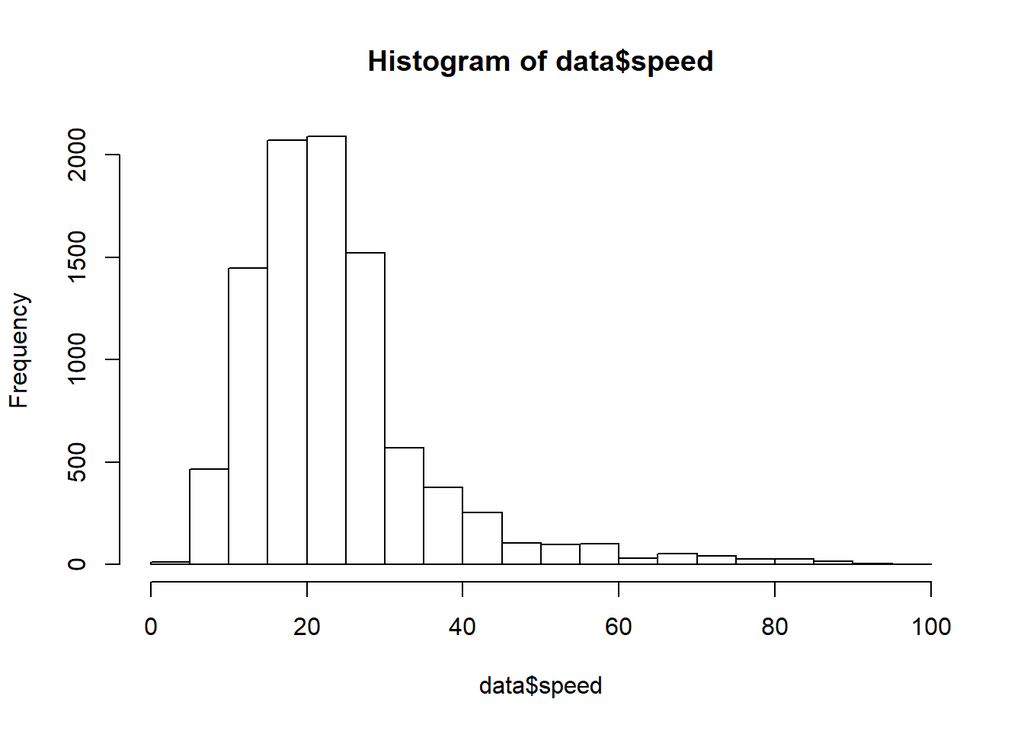

```r
hist(data$speed)
```

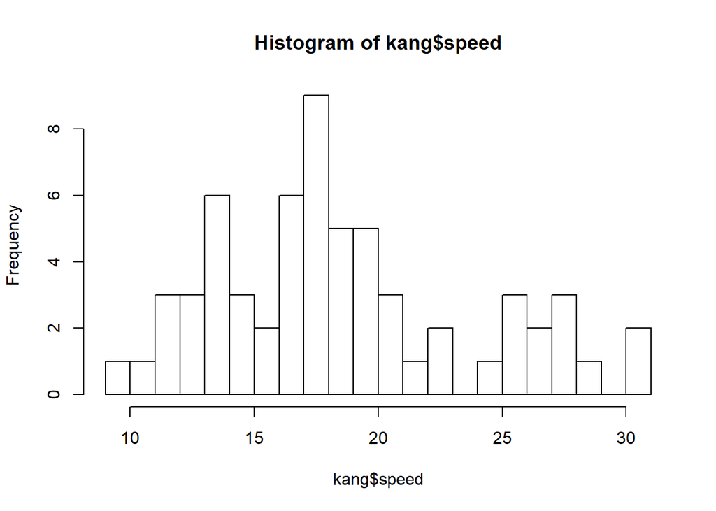

```r
kang <- data %>% filter(도로명 == "강남대로")
hist(kang$speed, breaks = 20)
```

- 정규분포로 이를 적합

$$y \sim N(\mu, \sigma^2)$$

## Run stan

### Stan Code

```r
# model
code1 <- '
data{
  int N; // number of obsverations
  real y[N]; // speed value
}

parameters{
  real mu; // mean
  real<lower=0> sigma; // standard deviation
}

model{
  y ~ normal(mu, sigma); // normal likelihood
}

generated quantities{
  real y_pred;
  y_pred = normal_rng(mu,sigma);
}
'
# compile models
model1 <- stan_model(model_code = code1, model_name="stanmodel")
```

### Sampling

```r
list1 <- list(N=nrow(kang), y = kang$speed)
fit1 <- sampling(model1, data = list1, seed = 123)
```

```r
print(fit1, probs = c(0.025,0.5,0.975))
```

```
## Inference for Stan model: stanmodel.
## 4 chains, each with iter=2000; warmup=1000; thin=1;
## post-warmup draws per chain=1000, total post-warmup draws=4000.
##
##           mean se_mean   sd    2.5%     50%   97.5% n_eff Rhat
## mu       18.52    0.01 0.67   17.23   18.51   19.89  2933    1
## sigma     5.29    0.01 0.48    4.44    5.25    6.32  3100    1
## y_pred   18.62    0.09 5.42    7.84   18.71   29.22  3938    1
## lp__   -131.78    0.02 1.00 -134.47 -131.48 -130.82  1628    1
##
## Samples were drawn using NUTS(diag_e) at Tue Oct 06 13:58:23 2020.
## For each parameter, n_eff is a crude measure of effective sample size,
## and Rhat is the potential scale reduction factor on split chains (at
## convergence, Rhat=1).
```

- 추정된 $\mu$, $\sigma$ 값
- `y_pred`: 추정된 모수를 바탕으로 생성된 예측 값

### Converged?

```r
fit1
```

```
## Inference for Stan model: stanmodel.
## 4 chains, each with iter=2000; warmup=1000; thin=1;
## post-warmup draws per chain=1000, total post-warmup draws=4000.
##
##           mean se_mean   sd    2.5%     25%     50%     75%   97.5% n_eff
## mu       18.52    0.01 0.67   17.23   18.08   18.51   18.97   19.89  2933
## sigma     5.29    0.01 0.48    4.44    4.95    5.25    5.58    6.32  3100
## y_pred   18.62    0.09 5.42    7.84   15.06   18.71   22.25   29.22  3938
## lp__   -131.78    0.02 1.00 -134.47 -132.14 -131.48 -131.08 -130.82  1628
##        Rhat
## mu        1
## sigma     1
## y_pred    1
## lp__      1
##
## Samples were drawn using NUTS(diag_e) at Tue Oct 06 13:58:23 2020.
## For each parameter, n_eff is a crude measure of effective sample size,
## and Rhat is the potential scale reduction factor on split chains (at
## convergence, Rhat=1).
```

- 충분히 큰 n_eff
- 1에 가까운 Rhat

### Traceplot

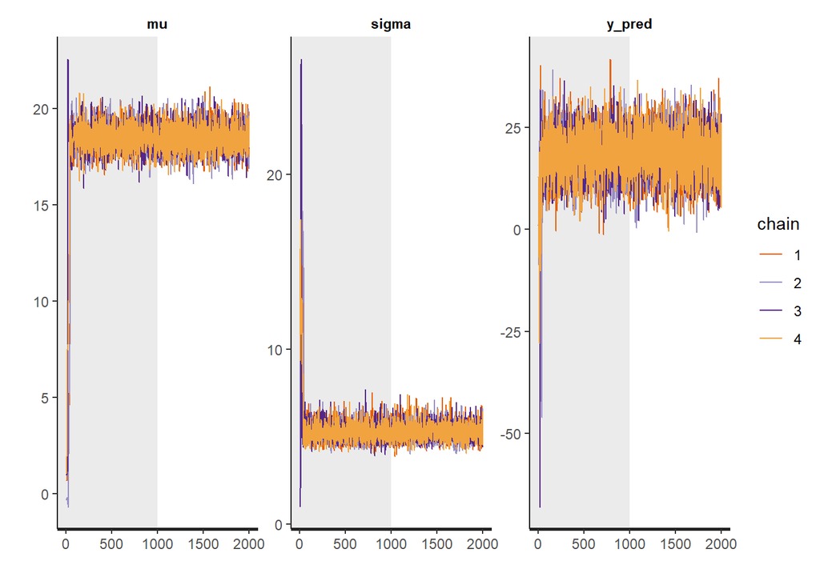

```r
traceplot(fit1, inc_warmup = TRUE)
```

- Traceplot을 통해 chain 이 잘 섞이고, 모수가 잘 수렴했음을 알 수 있다.

### Estimated Parameter

```
## ci_level: 0.8 (80% intervals)
```

```
## outer_level: 0.95 (95% intervals)
```

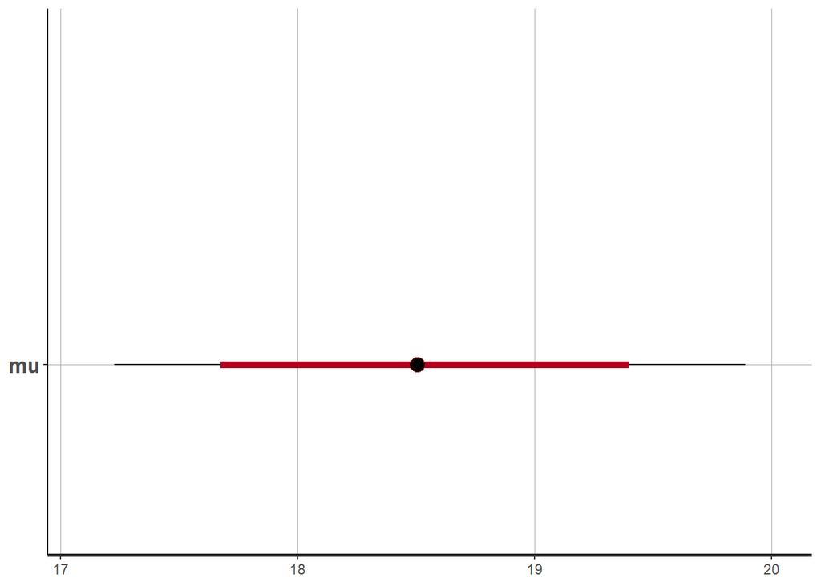

```r
plot(fit1, pars = c("mu"))
```

```
## ci_level: 0.8 (80% intervals)
## outer_level: 0.95 (95% intervals)
```

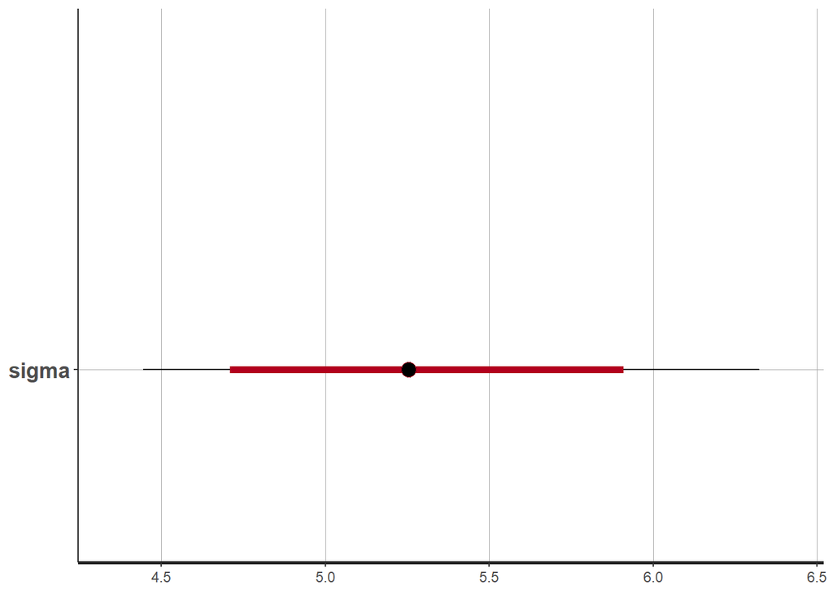

```r
plot(fit1, pars = c("sigma"))
```

* $\mu$, $\sigma$의 80%, 95% 베이즈 신뢰구간

### Extract posterior draws with `extract()` function

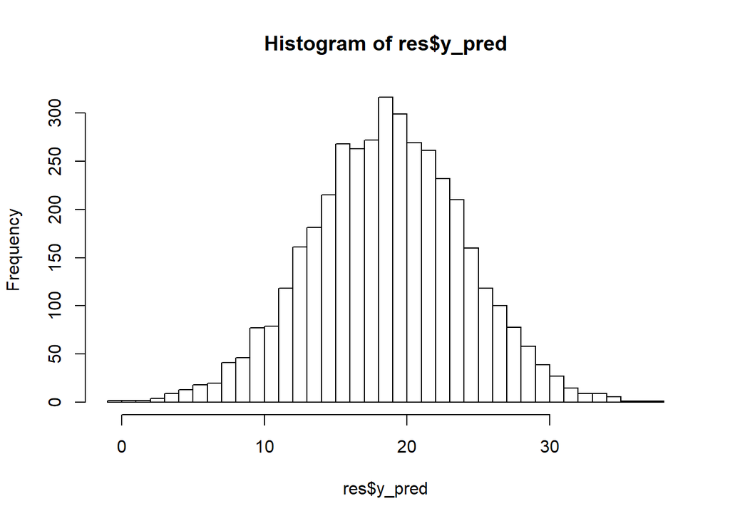

```r
res <- extract(fit1)
## save y_pred posterior draws
y_pred <- res$y_pred
hist(res$y_pred, breaks = 30)
```

- $\hat{\mu}, \hat{\sigma}$로 구한 예측값 `y_pred`의 히스토그램

## Plotting with `bayesplot` package

```r
library(bayesplot)
```

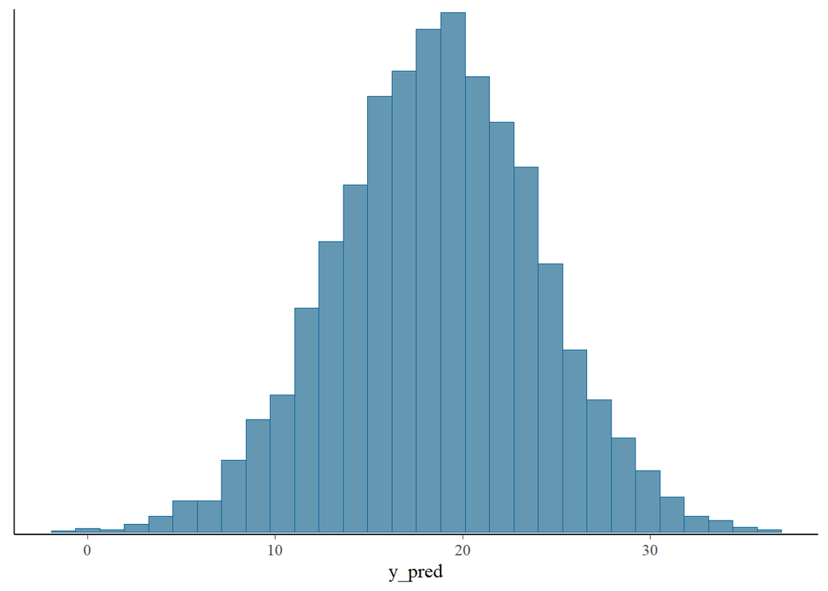

```r
mcmc_hist(fit1, "y_pred") # equivalent expression
```

### `mcmc_areas()`: estimated posterior density curves

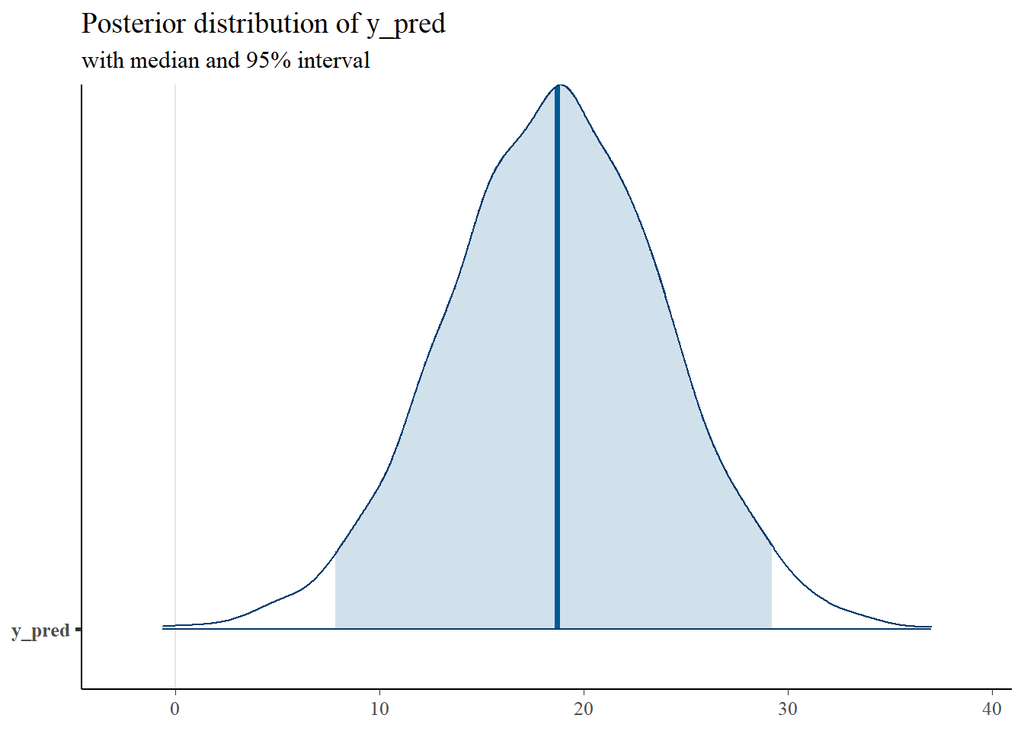

```r
mcmc_areas(fit1, "y_pred", prob = 0.95) +
  ggtitle("Posterior distribution of y_pred", "with median and 95% interval")
```

## **Frequentist vs. Bayesian**

### Frequentist way

- P-value를 통한 $\mu$의 검정

$$H_0 : \mu = 20 \ \ vs. \ H_1: \mu \neq 20$$

```r
t.test(kang$speed, mu = 20)
```

```
##
##  One Sample t-test
##
## data:  kang$speed
## t = -2.2525, df = 61, p-value = 0.0279
## alternative hypothesis: true mean is not equal to 20
## 95 percent confidence interval:
##  17.20432 19.83374
## sample estimates:
## mean of x
##  18.51903
```

- P-value = 0.0279 : 귀무가설이 참일때, 즉 **$\mu = 20$일 때** 우리의 데이터가 관찰될 확률이 0.0279로 0.05보다 작으므로 귀무가설을 기각한다.
- 95% 신뢰구간: (17.204 , 19.83374)
  - 모수 $\mu$가 (17.204 , 19.83374)에 포함될 확률이 95%다. **(X)** 잘못된 해석!
  - 모수 $\mu$의 95% 신뢰구간: $\mu \in \bar{y} \pm t_{n-1}(0.025) \frac{s}{\sqrt{n}}$
  - 이러한 방식으로 계속 신뢰구간을 구했을 때, 그 중 95%는 모수 $\mu$를 포함할 것이다.
  - 즉 빈도주의 접근의 신뢰구간은 Repeated Sampling 관점에서 해석되는 것으로, 모수 $\mu$에 대한 어떤 확률적 진술(probability statement)도 하지 못한다.

```r
# Frequentist approach
# Confidence Interval of mu (data # = 62)
upper <- mean(kang$speed) + qt(0.975,61) * sd(kang$speed)/sqrt(62)
lower <- mean(kang$speed) - qt(0.975,61) * sd(kang$speed)/sqrt(62)
ci <- c(lower, upper)
```

### Bayesian Way

- 모수에 대한 직접적인 확률적 진술이 가능하다.
- 데이터의 적용은 **prior** -> **posterior**로 불확실성(uncertainty)을 줄여나가며,
- 모수가 갖는 불확실성을 확률적으로 수량화(quantify)할 수 있다.

### 95% Bayesian credible interval(95% 베이즈 신뢰구간/신용구간)

- 모수 $\mu$에 대한 95% 신용구간:

```r
quantile(res$mu, c(0.025, 0.975))
```

```
##     2.5%    97.5%
## 17.22673 19.89063
```

- 모수 $\mu$가 (17.227, 19.891) 범위에 포함될 확률이 95%다.

### Posterior Probability 계산(p-value와 비교)

```r
# prob(speed > 20)
sum(res$mu > 20)/4000
```

```
## [1] 0.01625
```

- 평균 모수 $\mu$가 20보다 클 확률이 0.0162다.

## 여러 도로의 속도 분포 추정

- 강남대로, 테헤란로, 논현로는 서로 인접해있는 도로들이다.
- 서로 인접해있으므로 속도 분포가 유사할 것이라는 가정에 기반하여 이들의 속도 분포를 계층모형으로 추론하자

```r
kang <- data %>% filter(도로명 == "강남대로")
teh <-  data %>% filter(도로명 == "테헤란로")
non <- data %>% filter(도로명 == "논현로")
```

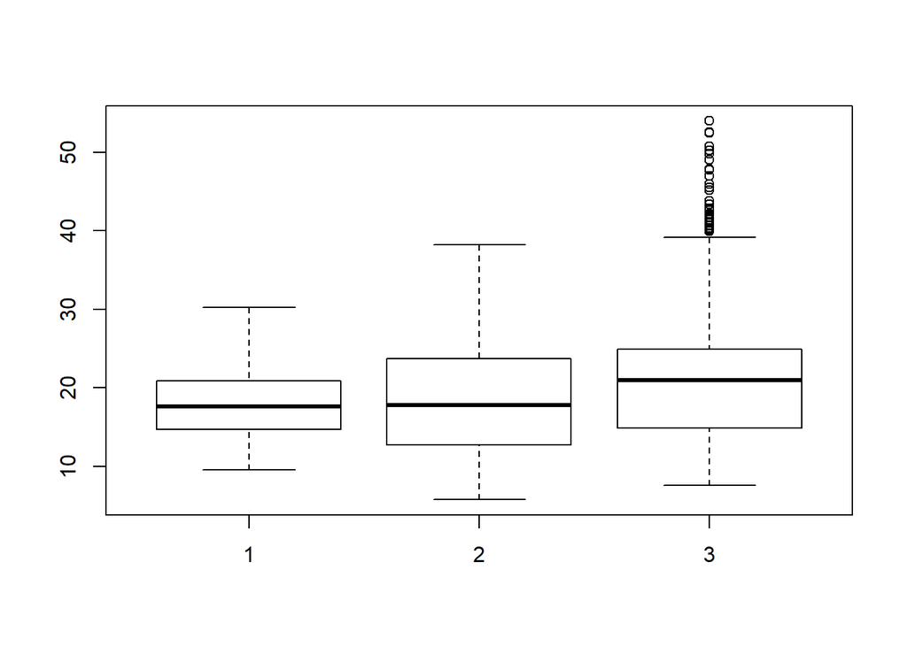

```r
boxplot(kang$speed, teh$speed, non$speed)
```

- 어느정도 유사성을 갖는 3개 도로의 속도 관찰값
- 3개의 속도 평균 모수 $\mu_1, \mu_2, \mu_3$ 가 동일한 분포에서 나왔다는 **계층모형**의 가정 가능
- 계층 구조 아래 서로 다른 3개의 정규분포 추정

$$y_1 \sim N(\mu_1, \sigma_1 ^2) \ , \\ y_2 \sim N(\mu_2, \sigma_2 ^2) \ , \\ y_3 \sim N(\mu_3, \sigma_3 ^2) \ ,\\ \mu_i \sim N(\mu_0, \sigma_0) \ , i = 1,2,3$$

### Stan code

```r
# model
code2 <- '
data{
  int N1;
  int N2;
  int N3;
  vector[N1] y1;
  vector[N2] y2;
  vector[N3] y3;
}


parameters{
  real mu0;
  real<lower = 0> sigma0;
  real mu[3];
  real<lower = 0> sigma[3];
}

model{
  for (i in 1:3){
    mu[i] ~ normal(mu0, sigma0); // hierarchical assumption
  }
  y1 ~ normal(mu[1], sigma[1]);
  y2 ~ normal(mu[2], sigma[2]);
  y3 ~ normal(mu[3], sigma[3]);
}


generated quantities{
  real y_pred[3];
  for (i in 1:3){
    y_pred[i] = normal_rng(mu[i], sigma[i]);
  }
}
'
# compile models
model2 <- stan_model(model_code = code2, model_name="stanmodel")
```

```r
list2 <- list(N1 = nrow(kang), N2 = nrow(teh), N3 = nrow(non),
              y1 = kang$speed, y2 = teh$speed, y3 = non$speed)
fit2 <- sampling(model2, data = list2,
                 control=list(adapt_delta=0.95))
```

- MCMC가 수렴하지 않는 현상 + `mu0`, `sigma0`의 n_eff가 낮다.

```r
fit2
```

```
## Inference for Stan model: stanmodel.
## 4 chains, each with iter=2000; warmup=1000; thin=1;
## post-warmup draws per chain=1000, total post-warmup draws=4000.
##
##               mean se_mean    sd     2.5%      25%      50%      75%
## mu0          20.08    2.23 30.89     8.52    18.23    19.56    20.81
## sigma0       14.22    4.49 73.85     0.92     1.86     3.18     6.50
## mu[1]        18.60    0.01  0.66    17.30    18.15    18.59    19.06
## mu[2]        18.63    0.01  0.33    17.99    18.41    18.63    18.86
## mu[3]        21.27    0.01  0.36    20.58    21.02    21.26    21.52
## sigma[1]      5.28    0.01  0.48     4.44     4.94     5.25     5.58
## sigma[2]      6.97    0.00  0.24     6.51     6.81     6.96     7.12
## sigma[3]      8.75    0.00  0.25     8.27     8.57     8.74     8.91
## y_pred[1]    18.57    0.08  5.28     8.10    15.09    18.58    22.06
## y_pred[2]    18.49    0.11  6.95     5.20    13.85    18.67    23.10
## y_pred[3]    21.27    0.15  8.73     3.79    15.54    21.23    27.09
## lp__      -2761.94    0.12  2.63 -2768.54 -2763.23 -2761.45 -2760.12
##              97.5% n_eff Rhat
## mu0          37.00   192 1.02
## sigma0       75.54   271 1.01
## mu[1]        19.90  3376 1.00
## mu[2]        19.26  3719 1.00
## mu[3]        22.00  3602 1.00
## sigma[1]      6.32  3253 1.00
## sigma[2]      7.46  3597 1.00
## sigma[3]      9.26  3548 1.00
## y_pred[1]    28.81  4056 1.00
## y_pred[2]    32.21  3848 1.00
## y_pred[3]    39.35  3464 1.00
## lp__      -2758.29   477 1.01
##
## Samples were drawn using NUTS(diag_e) at Tue Oct 06 14:01:15 2020.
## For each parameter, n_eff is a crude measure of effective sample size,
## and Rhat is the potential scale reduction factor on split chains (at
## convergence, Rhat=1).
```

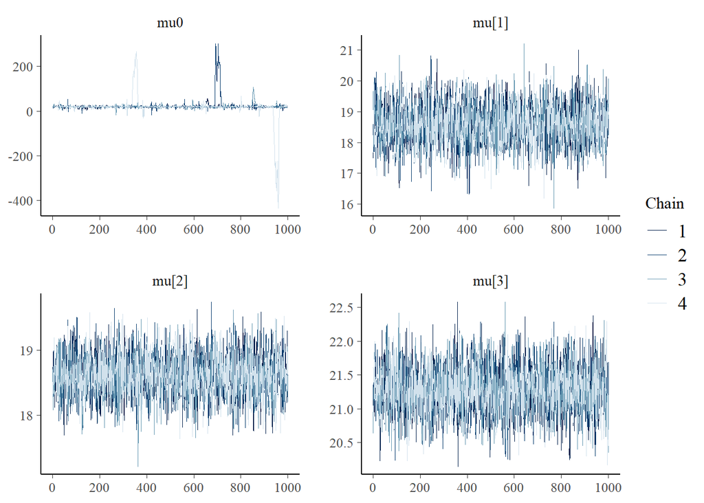

```r
mcmc_trace(fit2, regex_pars ="mu")
```

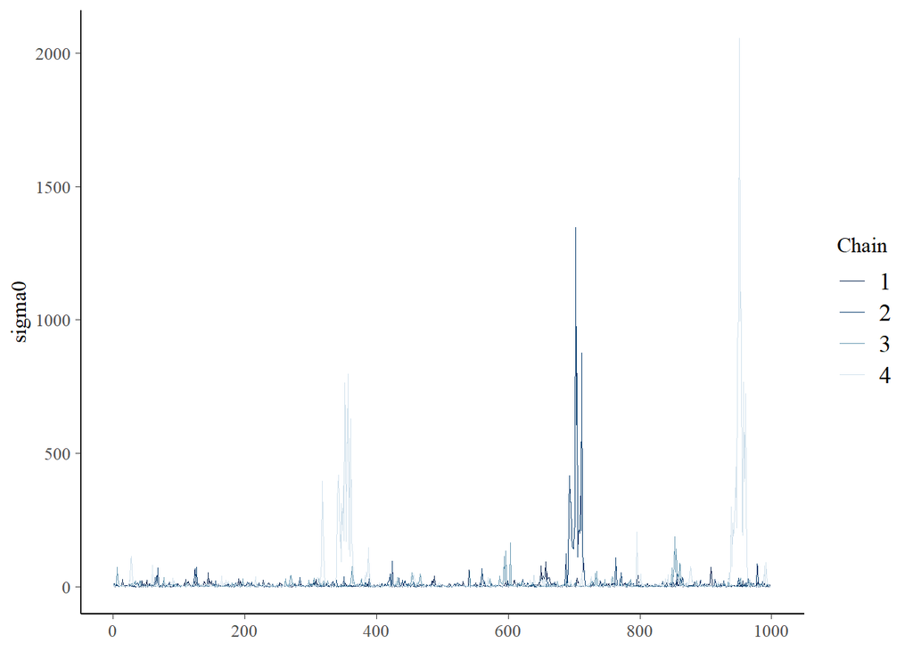

```r
mcmc_trace(fit2, pars ="sigma0")
```

- 정규분포보다 꼬리가 긴 코시분포(Cauchy distribution)를 $\mu_i$들의 분포로 사용

$$\mu_i \sim Cauchy(\mu_0, \sigma_0) \ , i = 1,2,3$$

```r
# model
code3 <- '
data{
  int N1;
  int N2;
  int N3;
  vector[N1] y1;
  vector[N2] y2;
  vector[N3] y3;
}

parameters{
  real mu0;
  real<lower = 0> sigma0;
  real mu[3];
  real<lower = 0> sigma[3];
}

model{
  for (i in 1:3){
    mu[i] ~ cauchy(mu0, sigma0); // Cauchy distribution
  }
  y1 ~ normal(mu[1], sigma[1]);
  y2 ~ normal(mu[2], sigma[2]);
  y3 ~ normal(mu[3], sigma[3]);
}


generated quantities{
  real y_pred[3];
  for (i in 1:3){
    y_pred[i] = normal_rng(mu[i], sigma[i]);
  }
}
'
# compile models
model3 <- stan_model(model_code = code3, model_name="stanmodel")
```

```r
# cauchy
fit3 <- sampling(model3, data = list2)
print(fit3, probs = c(0.025,0.5,0.975))
```

```
## Inference for Stan model: stanmodel.
## 4 chains, each with iter=2000; warmup=1000; thin=1;
## post-warmup draws per chain=1000, total post-warmup draws=4000.
##
##               mean se_mean    sd     2.5%      50%    97.5% n_eff Rhat
## mu0          21.83    1.32 15.99    10.36    19.22    71.95   148 1.03
## sigma0       10.83    2.76 37.84     0.34     2.49    91.03   188 1.02
## mu[1]        18.61    0.01  0.66    17.31    18.61    19.87  2755 1.00
## mu[2]        18.63    0.01  0.34    17.99    18.64    19.27  2699 1.00
## mu[3]        21.27    0.01  0.36    20.58    21.27    21.98  2077 1.00
## sigma[1]      5.28    0.01  0.51     4.39     5.24     6.40  2754 1.00
## sigma[2]      6.97    0.01  0.24     6.52     6.96     7.43  1749 1.00
## sigma[3]      8.74    0.00  0.25     8.27     8.73     9.23  3061 1.00
## y_pred[1]    18.67    0.08  5.36     8.19    18.72    29.18  4043 1.00
## y_pred[2]    18.47    0.11  6.95     4.92    18.35    31.93  4038 1.00
## y_pred[3]    21.25    0.14  8.81     4.22    21.22    38.24  3938 1.00
## lp__      -2762.21    0.18  2.76 -2769.44 -2761.62 -2758.39   241 1.02
##
## Samples were drawn using NUTS(diag_e) at Tue Oct 06 14:04:50 2020.
## For each parameter, n_eff is a crude measure of effective sample size,
## and Rhat is the potential scale reduction factor on split chains (at
## convergence, Rhat=1).
```

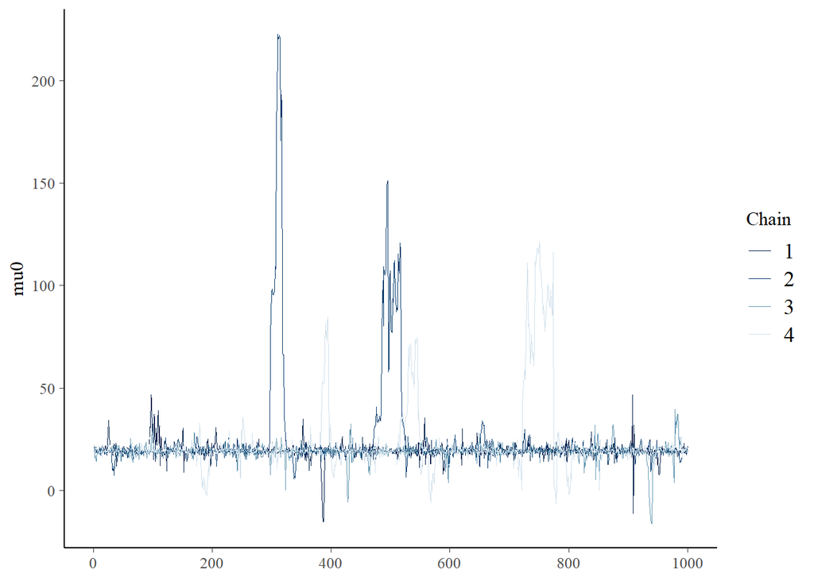

```r
mcmc_trace(fit3, regex_pars ="mu0")
```

### `mcmc_areas()` of $\mu$

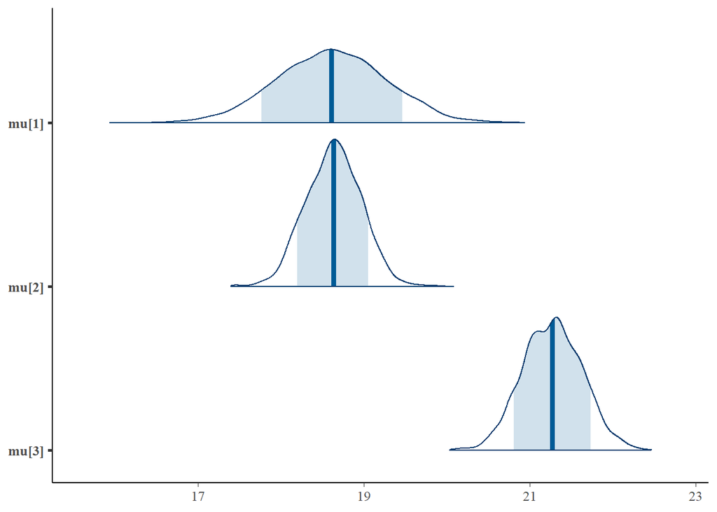

```r
mcmc_areas(fit3, pars = c("mu[1]","mu[2]","mu[3]"), prob = 0.8)
```

### `mcmc_areas()` of `y_pred`

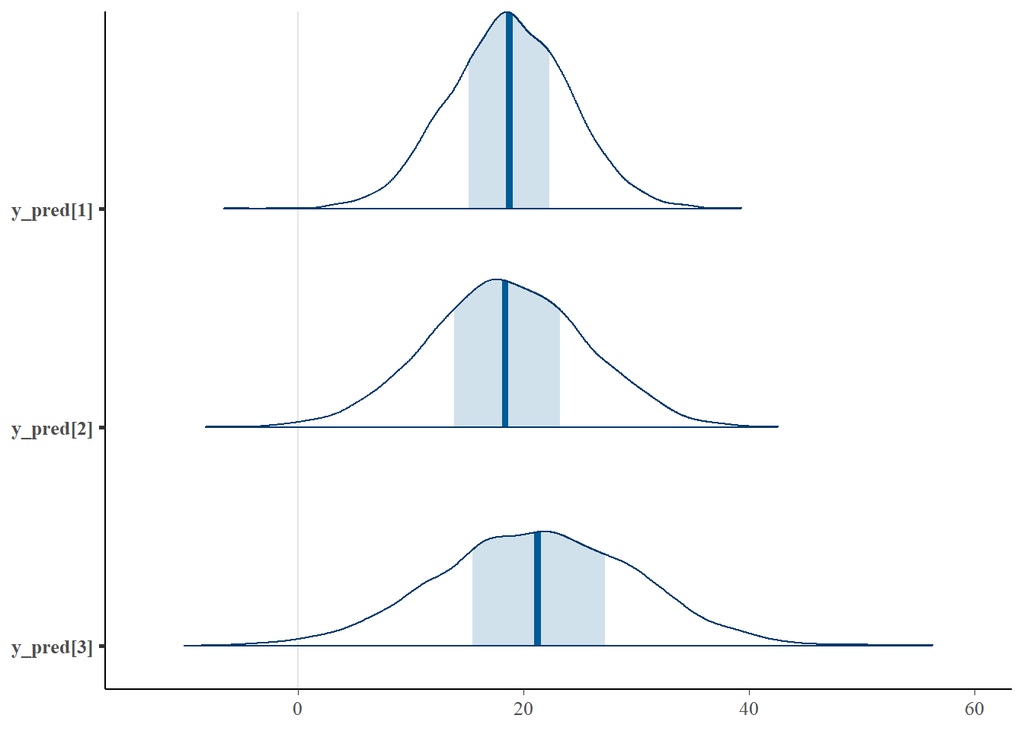

```r
mcmc_areas(fit3, pars = c("y_pred[1]", "y_pred[2]", "y_pred[3]"))
```